# Prompt Engineering - Módulo 2

Miguel Rodrigues Miguel.Rorigues.Train@gmail.com

01/09/2023

## Quem Sou

### Miguel Rodrigues

- Email: miguel.rodrigues.train@gmail.com
- LinkedIn: https://www.linkedin.com/in/miguel-r-a17101149/

Disponível para consultoria / formação na área de **Prompt Engineering**.

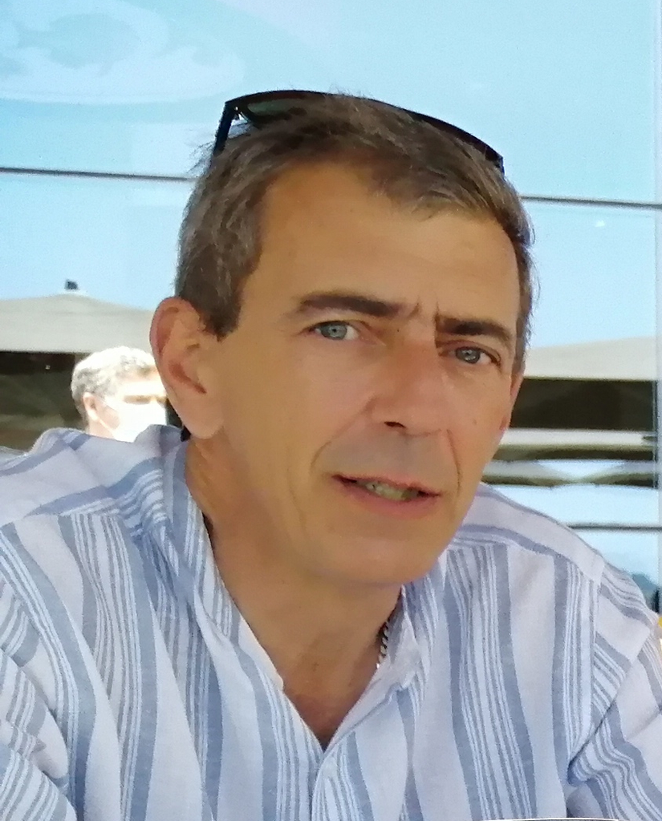

## Conteúdo Módulo2

Nesta módulo vamos continuar a detalhar o formato de uma instrução :

- Quem perguntar
- Contexto pergunta
- Tipo de resposta
- Certeza
- Tamanho
- Formato
- Língua

Todas as perguntas feitas neste módulo ao bard podem ser consultadas online [aqui](https://g.co/bard/share/9f724fbf656a) .

## Informação

Como vimos no modúlo anterior ambos os modelos respondem de forma distinta em conteúdo, mas semelhante em termos de informação para um formato comum.

Por razões de economia na apresentação do módulo vamos passar a considerar só as respostas do bard.

## Fazer Perguntas - Quem perguntar

Decisão do tipo de interlocutor (Exemplo: podemos perguntar sobre a metereologia para amanhã ao vizinho(a) ou ao(à) especialista da previsão do tempo).

```
  # Quem perguntar - comentador desportivo
  Responde Como um comentador desportivo
  # Contexto pergunta
  Considera só futebol
  no ano de 2010
  # Pergunta
  Quem ganhou o campeonato do Mundo.
  # Tipo de resposta pretendido
      # Certeza
      # Tamanho
      # Formato
      # Língua
```

```
  # Quem perguntar - Árbitro de Futebol
  Responde Como um Árbitro de Futebol
  # Contexto pergunta
  Considera só futebol
  no ano de 2010
  # Pergunta
  Quem ganhou o campeonato do Mundo.
  # Tipo de resposta pretendido
      # Certeza
      # Tamanho
      # Formato
      # Língua
```

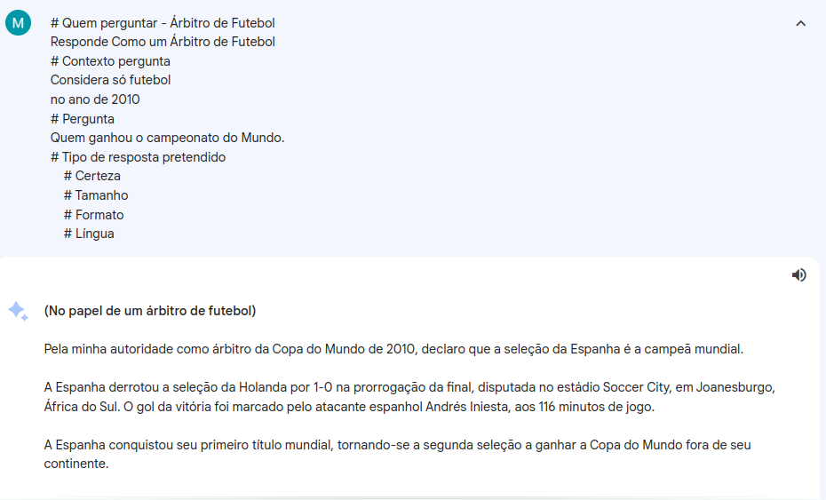

## Fazer Perguntas - Contexto pergunta

Nos exemplos anteriores já fornecemos o contexto de **só futebol** e **ano de 2010**. Vejamos o que acontece se **não fornecermos** o **desporto** ou o **ano**.

```
  # Quem perguntar
  # Contexto pergunta
  no ano de 2023
  # Pergunta
  Quem ganhou o campeonato do Mundo.
  # Tipo de resposta pretendido
      # Certeza
      # Tamanho
      # Formato
      # Língua
```

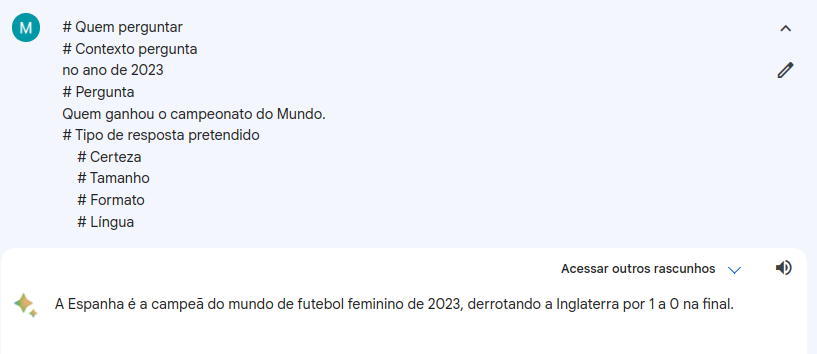

```
  # Quem perguntar
  # Contexto pergunta

  # Pergunta
  Quem ganhou o campeonato do Mundo.
  # Tipo de resposta pretendido
      # Certeza
      # Tamanho
      # Formato
      # Língua
```

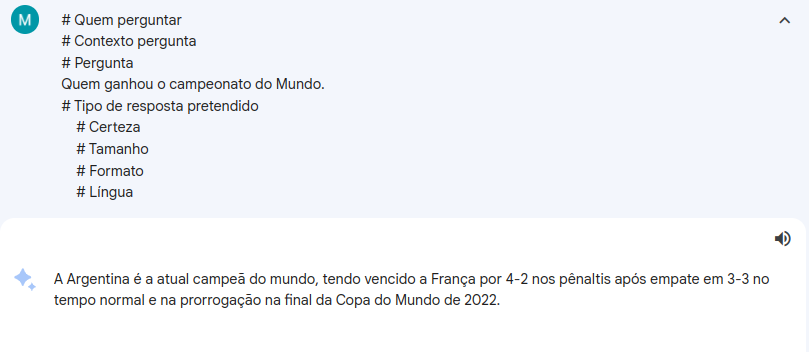

## Fazer Perguntas - Tipo de resposta - Certeza

Lembram-se de quando pedimos para **agir como um comentador desportivo** ? Vamos adicionar creatividade

```
  # Quem perguntar - comentador desportivo
  Responde Como um comentador desportivo
  # Contexto pergunta
  Considera só futebol
  no ano de 2010
  # Pergunta
  Quem ganhou o campeonato do Mundo.
  # Tipo de resposta pretendido
      # Certeza
      # Tamanho
      # Formato
      # Língua
```

```
  # Quem perguntar - Comentador Desportivo
  Responde Como um Comentador Desportivo
  # Contexto pergunta
  Considera só futebol
  no ano de 2010
  # Pergunta
  Quem ganhou o campeonato do Mundo.
  # Tipo de resposta pretendido
      # Certeza
      temperatura 0.9
      # Tamanho
      # Formato
      # Língua
```

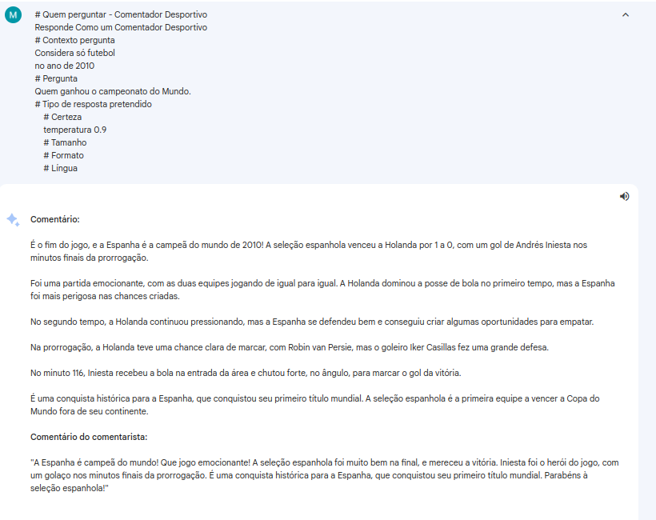

## Fazer Perguntas - Tipo de resposta - Tamanho

Podemos modificar o tamanho da resposta até 5000 palavras ( bard )

```
  # Quem perguntar - comentador desportivo
  Responde Como um comentador desportivo
  # Contexto pergunta
  Considera só futebol
  no ano de 2010
  # Pergunta
  Quem ganhou o campeonato do Mundo.
  # Tipo de resposta pretendido
      # Certeza
      # Tamanho
      # Formato
      # Língua
```

```
  # Quem perguntar - Comentador Desportivo
  Responde Como um Comentador Desportivo
  # Contexto pergunta
  Considera só futebol
  no ano de 2010
  # Pergunta
  Quem ganhou o campeonato do Mundo.
  # Tipo de resposta pretendido
      # Certeza
      # Tamanho
      resposta em 120 palavras.
      # Formato
      # Língua
```

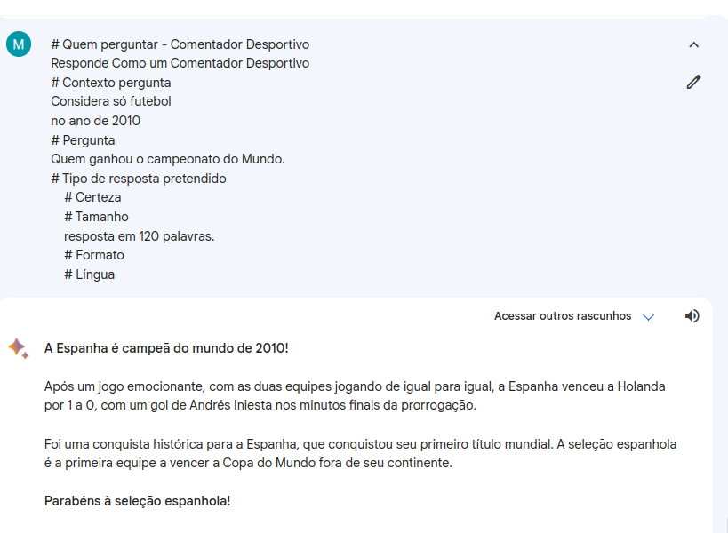

## Fazer Perguntas - Tipo de resposta - Língua

```
  # Quem perguntar - comentador desportivo
  Responde Como um comentador desportivo
  # Contexto pergunta
  Considera só futebol
  no ano de 2010
  # Pergunta
  Quem ganhou o campeonato do Mundo.
  # Tipo de resposta pretendido
      # Certeza
      # Tamanho
      # Formato
      # Língua
```

```
  # Quem perguntar - Comentador Desportivo
  Responde Como um Comentador Desportivo
  # Contexto pergunta
  Considera só futebol
  no ano de 2010
  # Pergunta
  Quem ganhou o campeonato do Mundo.
  # Tipo de resposta pretendido
      # Certeza
      # Tamanho
      # Formato
      # Língua
      Resposta em inglês e Espanhol.
```

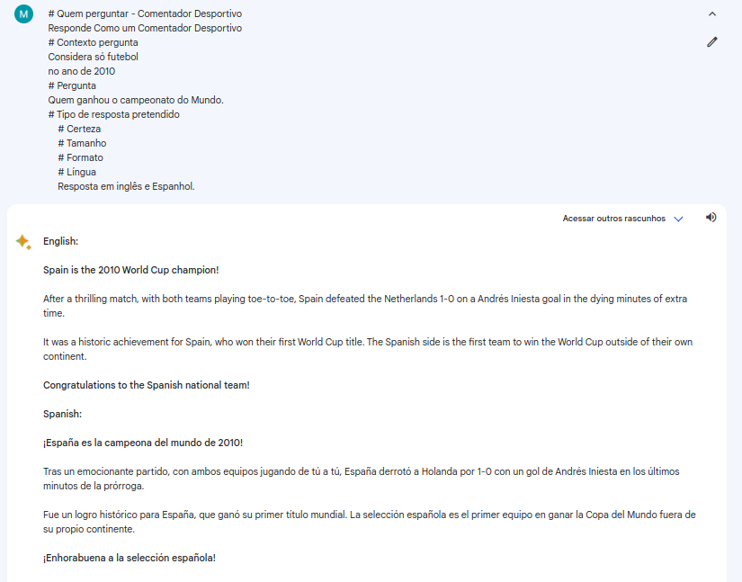

## Fazer Perguntas - Tipo de resposta - Formato

```
  # Quem perguntar - comentador desportivo
  Responde Como um comentador desportivo
  # Contexto pergunta
  Considera só futebol
  no ano de 2010
  # Pergunta
  Quem ganhou o campeonato do Mundo.
  # Tipo de resposta pretendido
      # Certeza
      # Tamanho
      # Formato
      # Língua
```

```
  # Quem perguntar - Comentador Desportivo
  Responde Como um Comentador Desportivo
  # Contexto pergunta
  Considera só futebol
  no ano de 2010
  # Pergunta
  Quem ganhou o campeonato do Mundo.
  # Tipo de resposta pretendido
      # Certeza
      # Tamanho
      # Formato
      resposta em yaml e texto
      # Língua
```

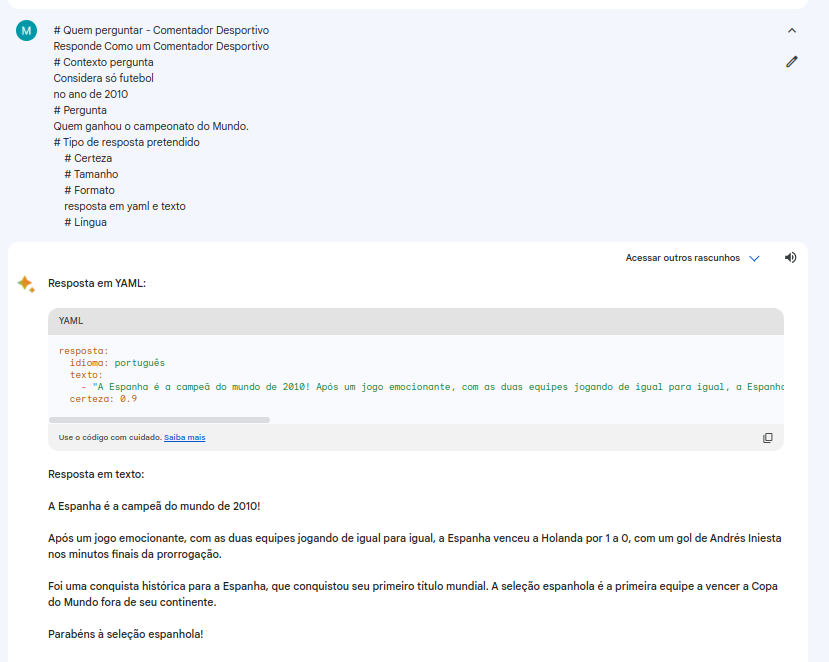